# ExtraaLearn Project

## Context

The EdTech industry has been surging in the past decade immensely, and according to a forecast, the Online Education market would be worth $286.62bn by 2023 with a compound annual growth rate (CAGR) of 10.26% from 2018 to 2023. The modern era of online education has enforced a lot in its growth and expansion beyond any limit. Due to having many dominant features like ease of information sharing, personalized learning experience, transparency of assessment, etc, it is now preferable to traditional education.

In the present scenario due to the Covid-19, the online education sector has witnessed rapid growth and is attracting a lot of new customers. Due to this rapid growth, many new companies have emerged in this industry. With the availability and ease of use of digital marketing resources, companies can reach out to a wider audience with their offerings. The customers who show interest in these offerings are termed as leads. There are various sources of obtaining leads for Edtech companies, like

- The customer interacts with the marketing front on social media or other online platforms.
- The customer browses the website/app and downloads the brochure
- The customer connects through emails for more information.

The company then nurtures these leads and tries to convert them to paid customers. For this, the representative from the organization connects with the lead on call or through email to share further details.

## Objective

ExtraaLearn is an initial stage startup that offers programs on cutting-edge technologies to students and professionals to help them upskill/reskill. With a large number of leads being generated on a regular basis, one of the issues faced by ExtraaLearn is to identify which of the leads are more likely to convert so that they can allocate resources accordingly. You, as a data scientist at ExtraaLearn, have been provided the leads data to:

- Analyze and build an ML model to help identify which leads are more likely to convert to paid customers,
- Find the factors driving the lead conversion process
- Create a profile of the leads which are likely to convert

## Data Description

The data contains the different attributes of leads and their interaction details with ExtraaLearn. The detailed data dictionary is given below.

**Data Dictionary**

- ID: ID of the lead
- age: Age of the lead
- current_occupation: Current occupation of the lead. Values include 'Professional','Unemployed',and 'Student'
- first_interaction: How did the lead first interacted with ExtraaLearn. Values include 'Website', 'Mobile App'
- profile_completed: What percentage of profile has been filled by the lead on the website/mobile app. Values include Low - (0-50%), Medium - (50-75%), High (75-100%)
- website_visits: How many times has a lead visited the website
- time_spent_on_website: Total time spent on the website
- page_views_per_visit: Average number of pages on the website viewed during the visits.
- last_activity: Last interaction between the lead and ExtraaLearn.
  - Email Activity: Seeking for details about program through email, Representative shared information with lead like brochure of program , etc
  - Phone Activity: Had a Phone Conversation with representative, Had conversation over SMS with representative, etc
  - Website Activity: Interacted on live chat with representative, Updated profile on website, etc
- print_media_type1: Flag indicating whether the lead had seen the ad of ExtraaLearn in the Newspaper.
- print_media_type2: Flag indicating whether the lead had seen the ad of ExtraaLearn in the Magazine.
- digital_media: Flag indicating whether the lead had seen the ad of ExtraaLearn on the digital platforms.
- educational_channels: Flag indicating whether the lead had heard about ExtraaLearn in the education channels like online forums, discussion threads, educational websites, etc.
- referral: Flag indicating whether the lead had heard about ExtraaLearn through reference.
- status: Flag indicating whether the lead was converted to a paid customer or not.

## Importing necessary libraries and data

```python
# Libraries to help with reading and manipulating data
import pandas as pd
import numpy as np

# Libaries to help with data visualization
import matplotlib.pyplot as plt
import seaborn as sns

# Importing the Machine Learning models required from Scikit-Learn
from sklearn.tree import DecisionTreeClassifier
from sklearn import tree
from sklearn.ensemble import RandomForestClassifier

# Importing the other functions required from Scikit-Learn
from sklearn.model_selection import train_test_split, GridSearchCV

# Import functions to get metric scores
from sklearn.metrics import confusion_matrix,classification_report

# Code to ignore warnings from function usage
import warnings;
warnings.filterwarnings('ignore')
```

## Data Overview

- Observations
- Sanity checks

```python
data = pd.read_csv('ExtraaLearn.csv') #Load in the data
```

```python
data.head() #View data and its layout
```

|  | ID | age | current_occupation | first_interaction | profile_completed | website_visits | time_spent_on_website | page_views_per_visit | last_activity | print_media_type1 | print_media_type2 | digital_media | educational_channels | referral | status |
| --- | --- | --- | --- | --- | --- | --- | --- | --- | --- | --- | --- | --- | --- | --- | --- |
| 0 | EXT001 | 57 | Unemployed | Website | High | 7 | 1639 | 1.861 | Website Activity | Yes | No | Yes | No | No | 1 |
| 1 | EXT002 | 56 | Professional | Mobile App | Medium | 2 | 83 | 0.320 | Website Activity | No | No | No | Yes | No | 0 |
| 2 | EXT003 | 52 | Professional | Website | Medium | 3 | 330 | 0.074 | Website Activity | No | No | Yes | No | No | 0 |
| 3 | EXT004 | 53 | Unemployed | Website | High | 4 | 464 | 2.057 | Website Activity | No | No | No | No | No | 1 |
| 4 | EXT005 | 23 | Student | Website | High | 4 | 600 | 16.914 | Email Activity | No | No | No | No | No | 0 |

```python
data.tail() #View data and its layout
```

|  | ID | age | current_occupation | first_interaction | profile_completed | website_visits | time_spent_on_website | page_views_per_visit | last_activity | print_media_type1 | print_media_type2 | digital_media | educational_channels | referral | status |
| --- | --- | --- | --- | --- | --- | --- | --- | --- | --- | --- | --- | --- | --- | --- | --- |
| 4607 | EXT4608 | 35 | Unemployed | Mobile App | Medium | 15 | 360 | 2.170 | Phone Activity | No | No | No | Yes | No | 0 |
| 4608 | EXT4609 | 55 | Professional | Mobile App | Medium | 8 | 2327 | 5.393 | Email Activity | No | No | No | No | No | 0 |
| 4609 | EXT4610 | 58 | Professional | Website | High | 2 | 212 | 2.692 | Email Activity | No | No | No | No | No | 1 |
| 4610 | EXT4611 | 57 | Professional | Mobile App | Medium | 1 | 154 | 3.879 | Website Activity | Yes | No | No | No | No | 0 |
| 4611 | EXT4612 | 55 | Professional | Website | Medium | 4 | 2290 | 2.075 | Phone Activity | No | No | No | No | No | 0 |

```python
data.shape #Shape of the data
```

```
(4612, 15)
```

The data contains 4612 rows and 15 columns

```python
data.info() #Identify the numerical and categorical columns
```

```
<class 'pandas.core.frame.DataFrame'>
RangeIndex: 4612 entries, 0 to 4611
Data columns (total 15 columns):
 #   Column                 Non-Null Count  Dtype
---  ------                 --------------  -----
 0   ID                     4612 non-null   object
 1   age                    4612 non-null   int64
 2   current_occupation     4612 non-null   object
 3   first_interaction      4612 non-null   object
 4   profile_completed      4612 non-null   object
 5   website_visits         4612 non-null   int64
 6   time_spent_on_website  4612 non-null   int64
 7   page_views_per_visit   4612 non-null   float64
 8   last_activity          4612 non-null   object
 9   print_media_type1      4612 non-null   object
 10  print_media_type2      4612 non-null   object
 11  digital_media          4612 non-null   object
 12  educational_channels   4612 non-null   object
 13  referral               4612 non-null   object
 14  status                 4612 non-null   int64
dtypes: float64(1), int64(4), object(10)
memory usage: 540.6+ KB
```

The data is made of

- 5 numerical columns: `age`, `website_visits`, `time_spent_on_website`, `page_views_per_visit`,`status`
- 10 categorical columns: `ID`, `current_occupation`, `first_interaction`, `profile_completed`, `last_activity`, `print_media_type1`, `print_media_type2`, `digital_media`, `educational_channels`, `referral`

There are no missing values in data.

```python
data.describe().T #Identify summary statistics of numerical columns
```

|  | count | mean | std | min | 25% | 50% | 75% | max |
| --- | --- | --- | --- | --- | --- | --- | --- | --- |
| age | 4612.0 | 46.201214 | 13.161454 | 18.0 | 36.00000 | 51.000 | 57.00000 | 63.000 |
| website_visits | 4612.0 | 3.566782 | 2.829134 | 0.0 | 2.00000 | 3.000 | 5.00000 | 30.000 |
| time_spent_on_website | 4612.0 | 724.011275 | 743.828683 | 0.0 | 148.75000 | 376.000 | 1336.75000 | 2537.000 |
| page_views_per_visit | 4612.0 | 3.026126 | 1.968125 | 0.0 | 2.07775 | 2.792 | 3.75625 | 18.434 |
| status | 4612.0 | 0.298569 | 0.457680 | 0.0 | 0.00000 | 0.000 | 1.00000 | 1.000 |

- `age` has a minimum value of 18 and a maximum value of 63. Customers are on average above 45 years of age.
- `time_spent_on_website` is in seconds and should be converted to minutes for interpretability.

```python
data.drop(columns = 'ID', inplace=True) #Drop ID as it is only a unique identifier
data['time_spent_on_website'] = data['time_spent_on_website']/60 #Convert time spent on the site from seconds to minutes
```

```python
#Prepare data for exploratory data analysis
cat_cols = data.select_dtypes(include = 'object').columns.tolist() #List out the categorical columns
num_cols = data.select_dtypes(include = ['int64','float64']).columns.tolist() #List out numerical columns
num_cols.remove('status') #Remove target variable from numerical columns list
```

```python
#Print the categories in each categorical column
for column in cat_cols:
    print(data[column].value_counts())
    print('-'*50)
```

```
current_occupation
Professional    2616
Unemployed      1441
Student          555
Name: count, dtype: int64
--------------------------------------------------
first_interaction
Website       2542
Mobile App    2070
Name: count, dtype: int64
--------------------------------------------------
profile_completed
High      2264
Medium    2241
Low        107
Name: count, dtype: int64
--------------------------------------------------
last_activity
Email Activity      2278
Phone Activity      1234
Website Activity    1100
Name: count, dtype: int64
--------------------------------------------------
print_media_type1
No     4115
Yes     497
Name: count, dtype: int64
--------------------------------------------------
print_media_type2
No     4379
Yes     233
Name: count, dtype: int64
--------------------------------------------------
digital_media
No     4085
Yes     527
Name: count, dtype: int64
--------------------------------------------------
educational_channels
No     3907
Yes     705
Name: count, dtype: int64
--------------------------------------------------
referral
No     4519
Yes      93
Name: count, dtype: int64
--------------------------------------------------
```

```python
data['status'].value_counts(normalize=True) #Print the conversion rates
```

```
status
0    0.701431
1    0.298569
Name: proportion, dtype: float64
```

## Exploratory Data Analysis (EDA)

- EDA is an important part of any project involving data.
- It is important to investigate and understand the data better before building a model with it.
- A few questions have been mentioned below which will help you approach the analysis in the right manner and generate insights from the data.
- A thorough analysis of the data, in addition to the questions mentioned below, should be done.

**Questions**

1. Leads will have different expectations from the outcome of the course and the current occupation may play a key role in getting them to participate in the program. Find out how current occupation affects lead status.
2. The company's first impression on the customer must have an impact. Do the first channels of interaction have an impact on the lead status?
3. The company uses multiple modes to interact with prospects. Which way of interaction works best?
4. The company gets leads from various channels such as print media, digital media, referrals, etc. Which of these channels have the highest lead conversion rate?
5. People browsing the website or mobile application are generally required to create a profile by sharing their personal data before they can access additional information.Does having more details about a prospect increase the chances of conversion?

## Data Preprocessing

- Missing value treatment (if needed)
- Feature engineering (if needed)
- Outlier detection and treatment (if needed)
- Preparing data for modeling
- Any other preprocessing steps (if needed)

## EDA

- It is a good idea to explore the data once again after manipulating it.

### Univariate: Numeric

```python
# Defining the hist_box() function
def hist_box(data, col):
    f, (ax_box, ax_hist) = plt.subplots(2, sharex=True, gridspec_kw={'height_ratios': (0.15, 0.85)}, figsize=(12, 6))
    # Adding a graph in each part
    plt.suptitle(col)
    sns.boxplot(data=data, x=col, ax=ax_box, showmeans=True) #Boxplot
    sns.histplot(data=data, x=col, kde=True, ax=ax_hist) #Histogram
    ax_hist.axvline(data[col].mean(), color = 'green', linestyle = '--') #Mean indication line
    ax_hist.axvline(data[col].median(), color = 'black', linestyle = '-') #Median indication line
    plt.show()
```

**Age**

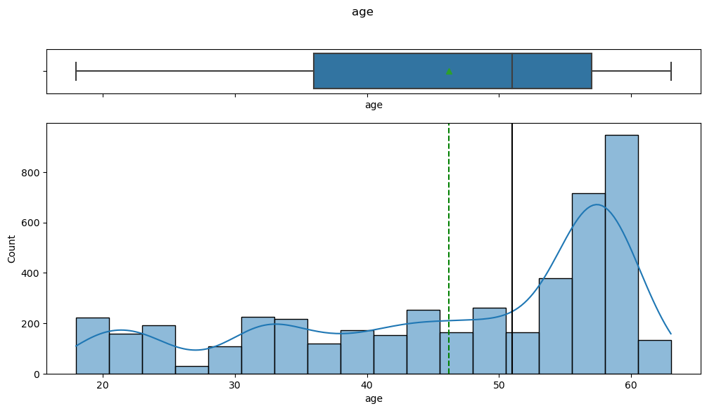

```python
#Age
hist_box(data,'age')
```

**Website Visits**

Most customers only visit the website twice or thrice before making the decision to pay for the services. The website is mostly only being used as a way to explore and be introduced to the services. It is doubtful wether it could be used as a means to convert leads to paying customers purely through website without significant investment.

**Time Spent on the Website**

**Page Views per Visit**

Customers on average view only 2-4 pages per visit. Though there are quite a few outliers of people visiting more than 10 pages, this number is still much lower than those visting only a few pages.

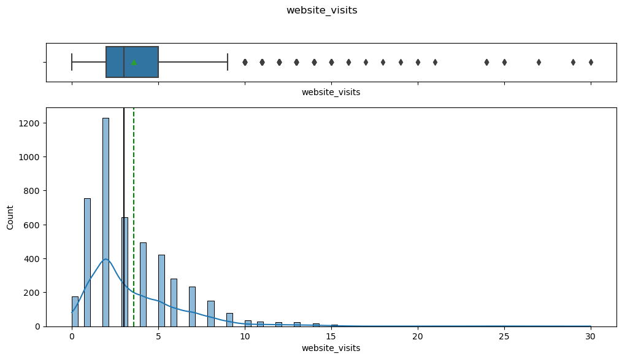

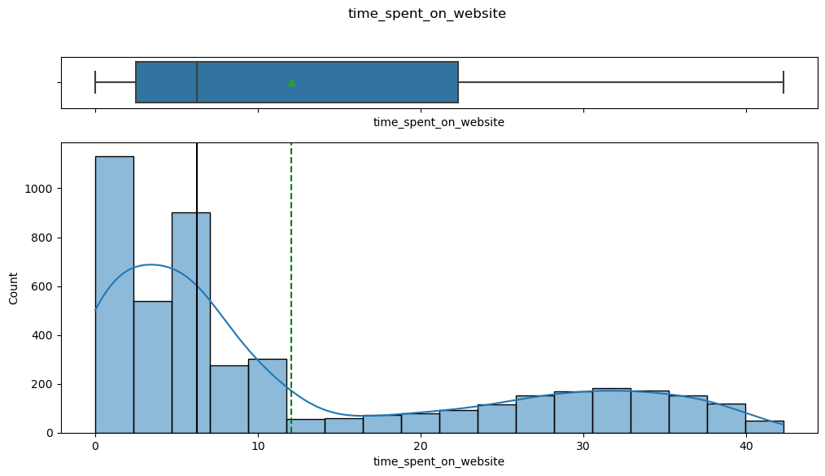

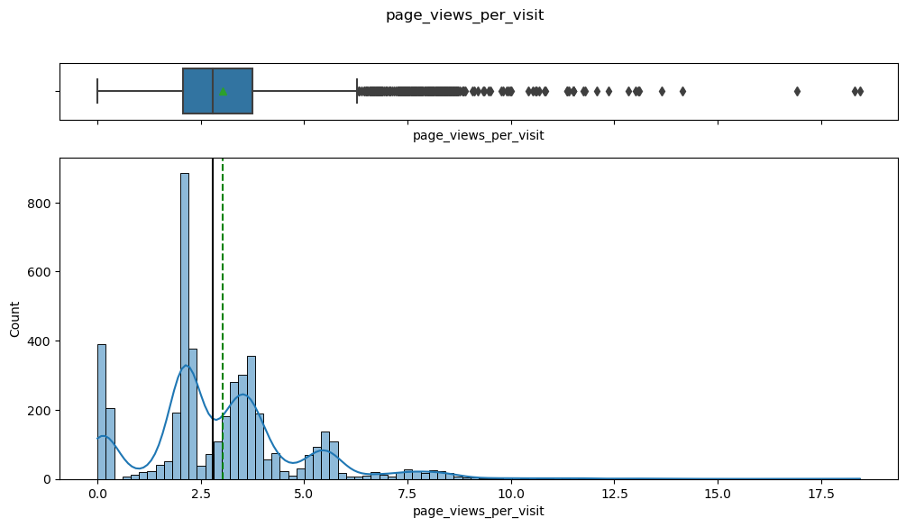

```python
#website_visits
hist_box(data,'website_visits')
#time_spent_on_website
hist_box(data,'time_spent_on_website')
#page_views_per_visit
hist_box(data,'page_views_per_visit')
```

### Univariate: Categorical

```python
def stacked_barplot(data, predictor, target):
    """
    Print the category counts and plot a stacked bar chart

    data: dataframe
    predictor: independent variable
    target: target variable
    """
    count = data[predictor].nunique()
    sorter = data[target].value_counts().index[-1]
    tab1 = pd.crosstab(data[predictor], data[target], margins = True).sort_values(
        by = sorter, ascending = False
    )
    print(tab1)
    print("-" * 120)
    tab = pd.crosstab(data[predictor], data[target], normalize = "index").sort_values(
        by = sorter, ascending = False
    )
    tab.plot(kind = "bar", stacked = True, figsize = (count + 1, 5))
    plt.legend(
        loc = "lower left",
        frameon = False,
    )
    plt.legend(loc = "upper left", bbox_to_anchor = (1, 1))
    plt.suptitle(target)
    plt.show()
```

**Current Occupation**

Most frequent customers are professionals who also have the highest conversion numbers as well. This is expected as they are looking to upskill/reskill themselves to move forward in their career. The next group is the unemployed followed by students who are attempting to gain skills to improve their profile to get into the job market. However, the number of student customers are low. This is a group to be targeted as there are probably a lot of students who definitely would use edutech services. So, targeting this group and improving the number of students looking at the service would be benificial.

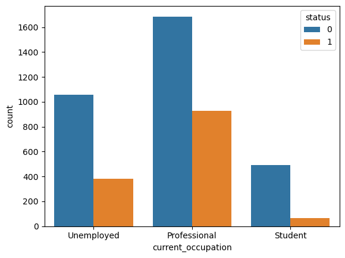

```python
#current_occupation
sns.countplot(data=data, x='current_occupation', hue='status')
```

**First Interaction**

The first point of intercation for most customers is through the website followed by the mobile app only slightly behind. However, the conversion rate through websites is much higher than through mobile app. This shows that the website markets the products better than the mobile app. Perhaps spending resources to improve the mobile app should be considered as a significant portion of customers interact through the mobile app.

```
status                0     1   All
first_interaction
All                3235  1377  4612
Website            1383  1159  2542
Mobile App         1852   218  2070
------------------------------------------------------------------------------------------------------------------------
```

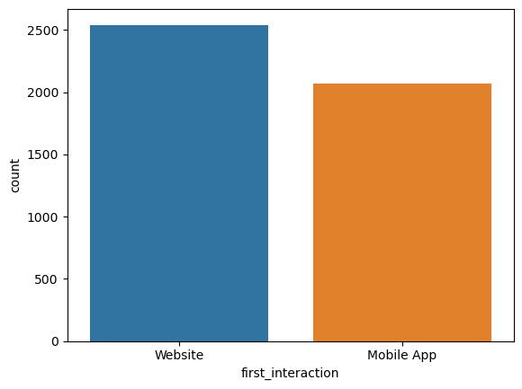

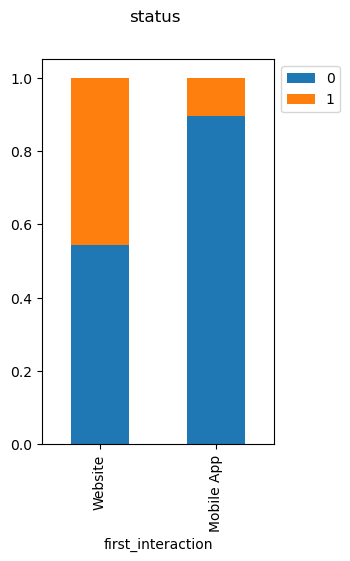

```python
#first_interaction
sns.countplot(data=data, x='first_interaction')
stacked_barplot(data=data,predictor='first_interaction', target='status')
```

**Profile Completed**

Most of the customers complete at least 50% or more of the profile. The greatest conversion rate is for those who complete 75% or more of the profile. So, incentivizing customers to complete more of the profile would lead to greater conversion rates. Perhaps providing rewards, discounts or bonuses for completing a certain amount of the profile would help.

```
status                0     1   All
profile_completed
All                3235  1377  4612
High               1318   946  2264
Medium             1818   423  2241
Low                  99     8   107
------------------------------------------------------------------------------------------------------------------------
```

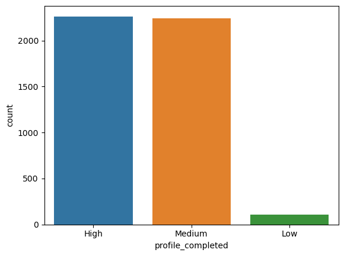

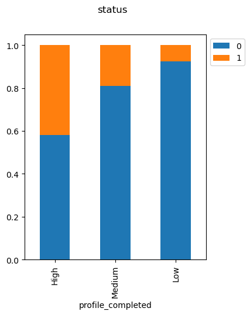

```python
#profile_completed
sns.countplot(data=data, x='profile_completed')
stacked_barplot(data=data,predictor='profile_completed', target='status')
```

**Last Activity**

The most common form of last interaction is through email. However, the conversion rate through email is much lower than through website. Interaction through phone is similar to interaction through website but the conversion rate is even lower. Focusing on marketing better through email might be an avenue to capture and convert more leads.

```
status               0     1   All
last_activity
All               3235  1377  4612
Email Activity    1587   691  2278
Website Activity   677   423  1100
Phone Activity     971   263  1234
------------------------------------------------------------------------------------------------------------------------
```

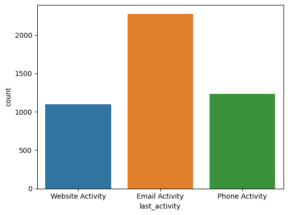

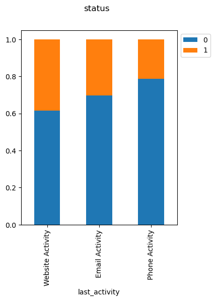

```python
#last_activity
sns.countplot(data=data, x='last_activity')
stacked_barplot(data=data,predictor='last_activity', target='status')
```

**Advert Channel**

None of the advertisement channels are a good way to advertise the services. Most customers do not seem to have learnt about the services through these channels. However, of the advertisement channels, customers predominantly hear about the product through education channels followed by digital media.

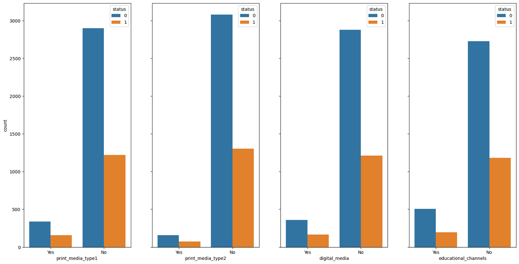

```python
#Advert channels
flag = 0 #Indicate subplot index
f, axs = plt.subplots(1,4,sharey=True,figsize=[20,10]) #Plot all adverts in a subplot
for col in cat_cols[4:8]:
    sns.countplot(data=data, x=col, hue = 'status', ax=axs[flag], order = ['Yes', 'No']) #Plot the countplot for each channel
    flag = flag+1 #Increment subplot index
for ax in axs.flat:
    ax.label_outer() #Remove x-labels from inner plots
```

**Referrals**

Referrals seem to be a good way to convert a lead. A customer who was referred to the service overwhelmingly converted to paid customers. Giving rewards to existing customers for providing referrals would encourage referrals.

```
status       0     1   All
referral
All       3235  1377  4612
No        3205  1314  4519
Yes         30    63    93
------------------------------------------------------------------------------------------------------------------------
```

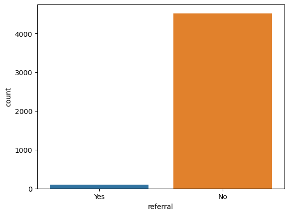

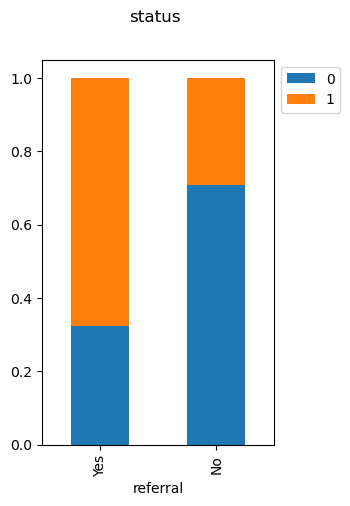

```python
#referral
sns.countplot(data=data, x='referral', order = ['Yes', 'No'])
stacked_barplot(data=data,predictor='referral', target='status')
```

**Summary**

### Multivariate

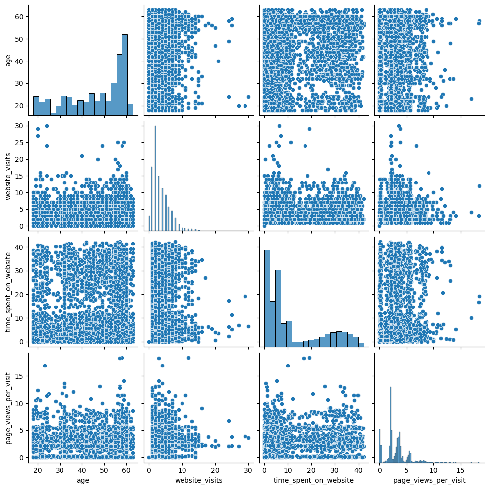

```python
sns.pairplot(data=data[num_cols])
```

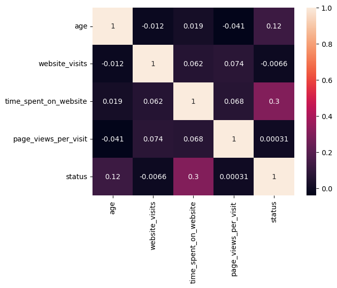

```python
sns.heatmap(data.corr(numeric_only=True), annot=True)
```

There does not seem to be any correlation between anyone of the columns. There is a slight positive correlation between time spent on the website and if they became a paid customer. But it is not very high either.

## Building a Decision Tree model

```python
df = data.copy() #Make a copy of the data set to work with
```

```python
df.replace({'Yes':1, 'No':0},inplace=True) #Convert all yes and no to numeric/bool
#Convert ctegorical columns into numeric using dummy variables
df = pd.get_dummies(df, columns = ['current_occupation', 'first_interaction', 'profile_completed', 'last_activity'])
```

```python
df.info() #Check new dtypes
```

```
<class 'pandas.core.frame.DataFrame'>
RangeIndex: 4612 entries, 0 to 4611
Data columns (total 21 columns):
 #   Column                           Non-Null Count  Dtype
---  ------                           --------------  -----
 0   age                              4612 non-null   int64
 1   website_visits                   4612 non-null   int64
 2   time_spent_on_website            4612 non-null   float64
 3   page_views_per_visit             4612 non-null   float64
 4   print_media_type1                4612 non-null   int64
 5   print_media_type2                4612 non-null   int64
 6   digital_media                    4612 non-null   int64
 7   educational_channels             4612 non-null   int64
 8   referral                         4612 non-null   int64
 9   status                           4612 non-null   int64
 10  current_occupation_Professional  4612 non-null   bool
 11  current_occupation_Student       4612 non-null   bool
 12  current_occupation_Unemployed    4612 non-null   bool
 13  first_interaction_Mobile App     4612 non-null   bool
 14  first_interaction_Website        4612 non-null   bool
 15  profile_completed_High           4612 non-null   bool
 16  profile_completed_Low            4612 non-null   bool
 17  profile_completed_Medium         4612 non-null   bool
 18  last_activity_Email Activity     4612 non-null   bool
 19  last_activity_Phone Activity     4612 non-null   bool
 20  last_activity_Website Activity   4612 non-null   bool
dtypes: bool(11), float64(2), int64(8)
memory usage: 410.0 KB
```

```python
X = df.drop(columns = 'status') #Create independent variable
Y = df['status'] #Create dependent variable
```

```python
# Splitting the dataset into train and test datasets in 70:30 split
x_train, x_test, y_train, y_test = train_test_split(X, Y, test_size = 0.3, shuffle = True, random_state = 1, stratify = Y)
```

```python
#Defining precission, recall, f1 score and plotting the confusion matrix
def metrics_score(actual, predicted):
    print(classification_report(actual, predicted))

    cm = confusion_matrix(actual, predicted)
    plt.figure(figsize=(8,5))

    sns.heatmap(cm, annot=True,  fmt='.2f')
    plt.ylabel('Actual')
    plt.xlabel('Predicted')
    plt.show()
```

```python
#Defining a function to visualize decision trees
def DecisionTree_Visualizer(predictors,classifier,depth=None):
    feature_names = list(predictors.columns)
    plt.figure(figsize=(20, 10))
    out = tree.plot_tree(
        classifier,
        max_depth = depth,
        feature_names=feature_names,
        filled=True,
        fontsize=9,
        node_ids=False,
        class_names=None, #Using older version of scikit-learn. Don't have class_names=True option
    )
```

```python
dt_class_model = DecisionTreeClassifier(random_state=1) #Create a decision tree model
dt_class_model.fit(x_train,y_train) #Training the tree on training data
```

```
DecisionTreeClassifier(random_state=1)
```

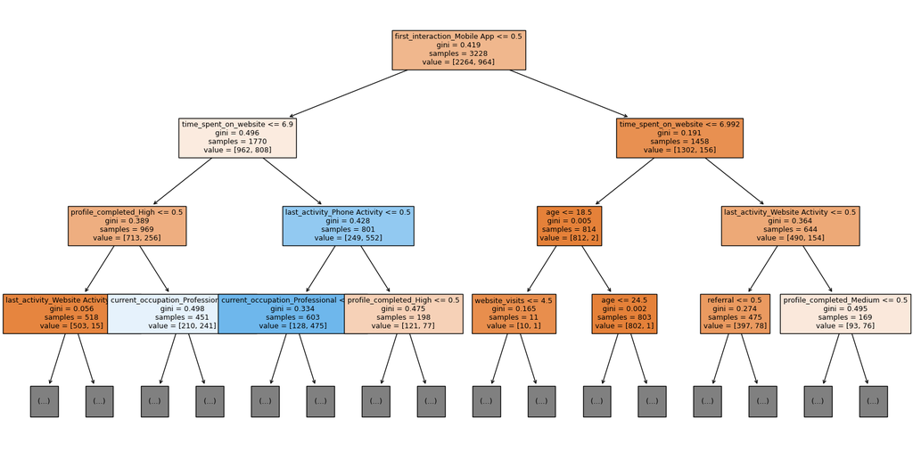

```python
DecisionTree_Visualizer(x_train,dt_class_model,depth = 3)
```

```
              precision    recall  f1-score   support

           0       1.00      1.00      1.00      2264
           1       1.00      1.00      1.00       964

    accuracy                           1.00      3228
   macro avg       1.00      1.00      1.00      3228
weighted avg       1.00      1.00      1.00      3228
```

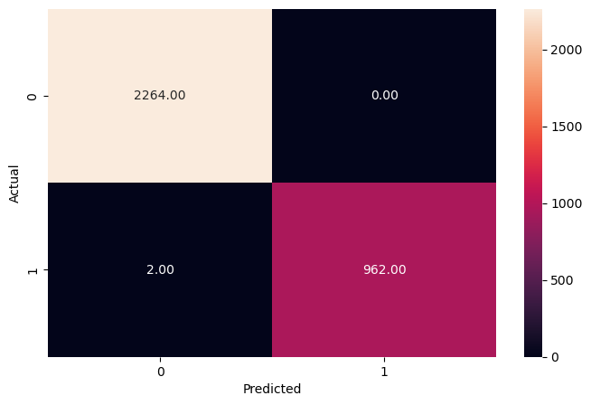

```python
#Checking the performance of the decision tree to training data
dt_class_pred_train = dt_class_model.predict(x_train)
metrics_score(y_train, dt_class_pred_train)
```

```
              precision    recall  f1-score   support

           0       0.85      0.85      0.85       971
           1       0.65      0.65      0.65       413

    accuracy                           0.79      1384
   macro avg       0.75      0.75      0.75      1384
weighted avg       0.79      0.79      0.79      1384
```

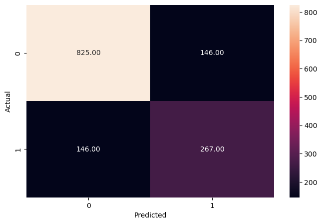

```python
#Checking the performance of the decision tree on the test data
dt_class_pred_test = dt_class_model.predict(x_test)
metrics_score(y_test, dt_class_pred_test)
```

## Do we need to prune the tree?

Clearly the decision tree is overfitting to the training data as the f1 score on training data is much higher than on test data. So, we need to prune the tree. The tree will be pruned to maximize the recall statistic as you want to minimize false negatives and catch as many potential leads as possible.

```python
dt_class_tuned = DecisionTreeClassifier(random_state=1)

# Grid of parameters to choose from
parameters = {
    "max_depth": np.arange(1,40,5), #Original tree has a depth of 40
    "max_leaf_nodes": [50, 75, 150, 250],
    "min_samples_split": [10, 20, 30, 50, 70],
}
# Run the grid search
grid_obj = GridSearchCV(dt_class_tuned, parameters, cv=5,scoring='recall',n_jobs=-1)
grid_obj = grid_obj.fit(x_train, y_train)

# Set the tree to the best combination of parameters
dt_class_tuned = grid_obj.best_estimator_

# Fit the best tree to the data.
dt_class_tuned.fit(x_train, y_train)
```

```
DecisionTreeClassifier(max_depth=6, max_leaf_nodes=50, min_samples_split=70,
                       random_state=1)
```

```
              precision    recall  f1-score   support

           0       0.92      0.90      0.91      2264
           1       0.78      0.81      0.80       964

    accuracy                           0.88      3228
   macro avg       0.85      0.86      0.85      3228
weighted avg       0.88      0.88      0.88      3228
```

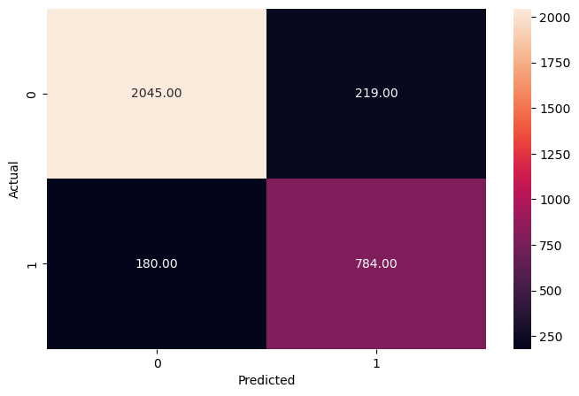

```python
#Checking the performance of the pruned decision tree to training data
dt_class_pred_train_tuned = dt_class_tuned.predict(x_train)
metrics_score(y_train, dt_class_pred_train_tuned)
```

```
              precision    recall  f1-score   support

           0       0.90      0.89      0.89       971
           1       0.75      0.76      0.75       413

    accuracy                           0.85      1384
   macro avg       0.82      0.83      0.82      1384
weighted avg       0.85      0.85      0.85      1384
```

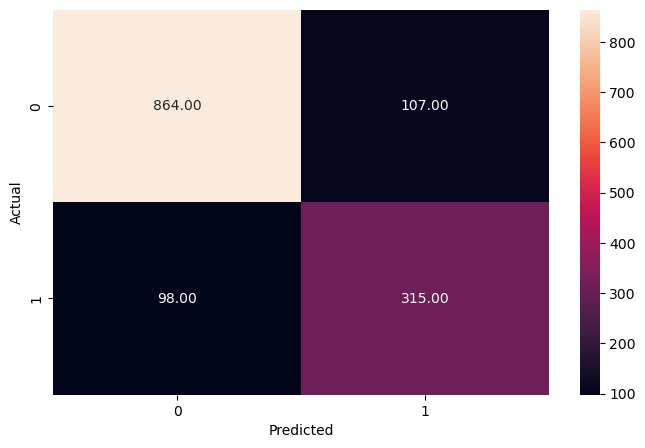

```python
#Checking the performance of the pruned decision tree to test data
dt_class_pred_test_tuned = dt_class_tuned.predict(x_test)
metrics_score(y_test, dt_class_pred_test_tuned)
```

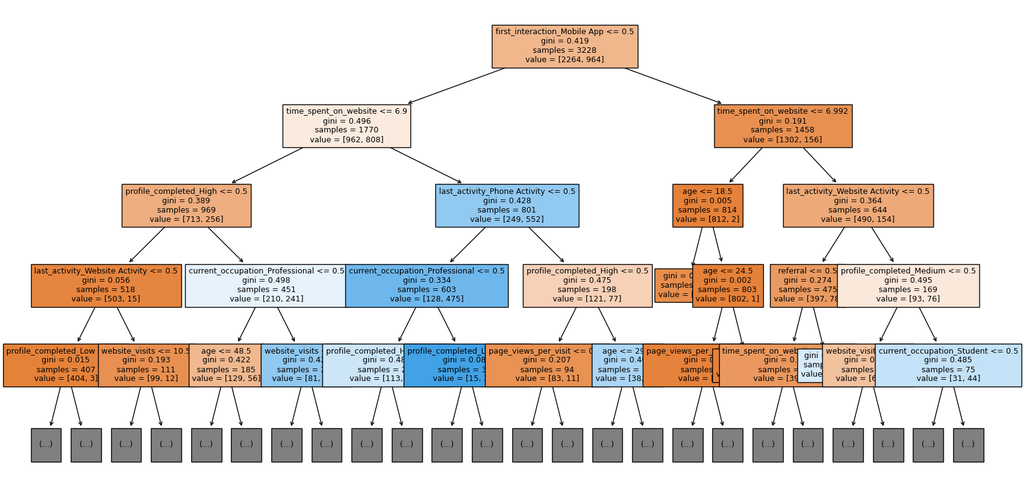

```python
DecisionTree_Visualizer(x_train,dt_class_tuned,depth=4)
```

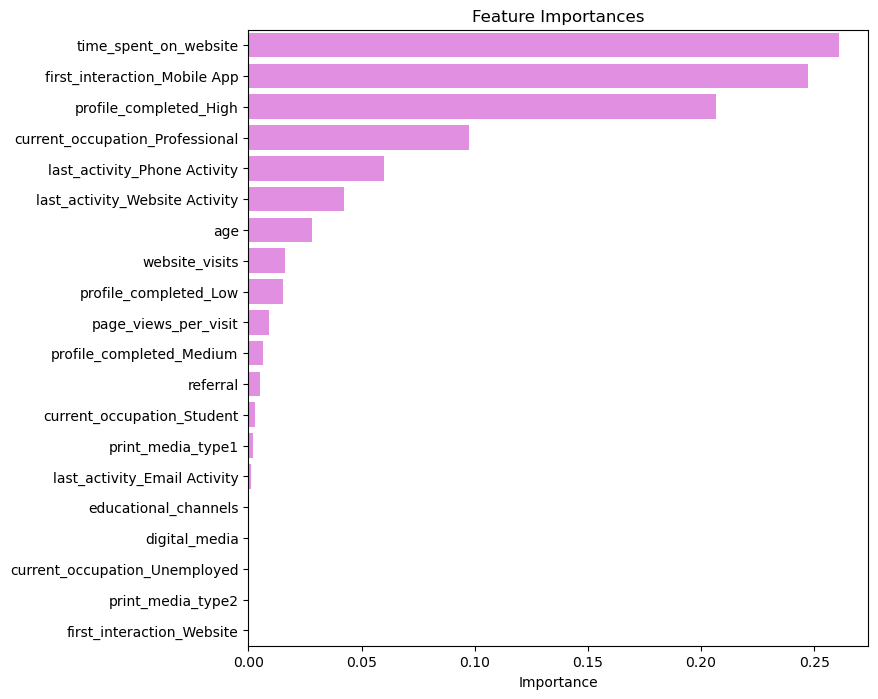

```python
#List out the features on which the tree splits and their importances
importances = dt_class_tuned.feature_importances_

columns = x_train.columns

importance_dt = pd.DataFrame(importances, index = columns, columns = ['Importance']).sort_values(by = 'Importance', ascending = False)


plt.figure(figsize=(8, 8))
plt.title("Feature Importances")
sns.barplot(x = importance_dt.Importance, y = importance_dt.index, color="violet")
```

From the decision tree, it can be seen that the most important factor that influences a lead to convert is how much time they spend on the website. This is followed by initial interaction through mobile app. Focusing on improving the website and mobile app should help convert more leads. Especially because the next most important factor is high profile completion. Improving the web and mobile app experience would be important to encouraging profile completion.

## Building a Random Forest model

```python
rf_class_model = RandomForestClassifier(random_state=1) #Create a random forest tree model
rf_class_model.fit(x_train,y_train) #Training the random forest on training data
```

```
RandomForestClassifier(random_state=1)
```

```
              precision    recall  f1-score   support

           0       1.00      1.00      1.00      2264
           1       1.00      1.00      1.00       964

    accuracy                           1.00      3228
   macro avg       1.00      1.00      1.00      3228
weighted avg       1.00      1.00      1.00      3228
```

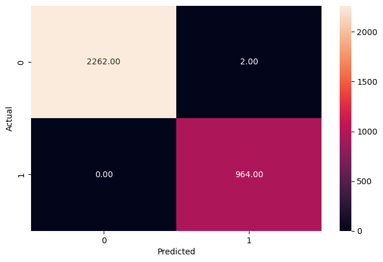

```python
#Checking the performance of the random forest to training data
rf_class_pred_train = rf_class_model.predict(x_train)
metrics_score(y_train, rf_class_pred_train)
```

```
              precision    recall  f1-score   support

           0       0.88      0.91      0.90       971
           1       0.77      0.72      0.75       413

    accuracy                           0.85      1384
   macro avg       0.83      0.81      0.82      1384
weighted avg       0.85      0.85      0.85      1384
```

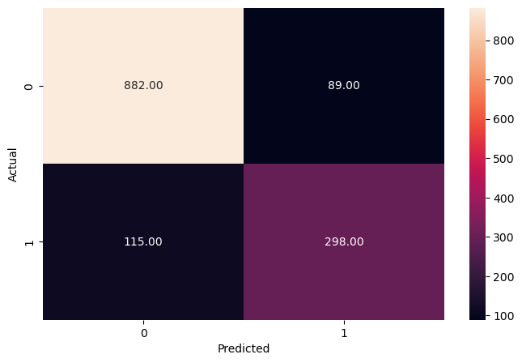

```python
#Checking the performance of the random forest to test data
rf_class_pred_test = rf_class_model.predict(x_test)
metrics_score(y_test, rf_class_pred_test)
```

## Do we need to prune the tree?

Yes, the random forest tree needs to be pruned as it is clearly overfitting.

```python
# Choose the random forest classifier.
rf_estimator = RandomForestClassifier(random_state=1)

# Grid of parameters to choose from
parameters = {
    "max_depth": np.arange(1,40,5),
    "max_leaf_nodes": [50, 75, 150, 250],
    "min_samples_split": [10, 30, 50, 70],
}
# Run the grid search
rf_grid_obj = GridSearchCV(rf_estimator, parameters, cv=5,scoring='f1',n_jobs=-1)
rf_grid_obj = rf_grid_obj.fit(x_train, y_train)

# Set the forest to the best combination of parameters
rf_estimator = rf_grid_obj.best_estimator_

# Fit the best forest to the data.
rf_estimator.fit(x_train, y_train)
```

```
RandomForestClassifier(max_depth=11, max_leaf_nodes=250, min_samples_split=10,
                       random_state=1)
```

```
              precision    recall  f1-score   support

           0       0.92      0.95      0.93      2264
           1       0.86      0.81      0.84       964

    accuracy                           0.91      3228
   macro avg       0.89      0.88      0.89      3228
weighted avg       0.91      0.91      0.91      3228
```

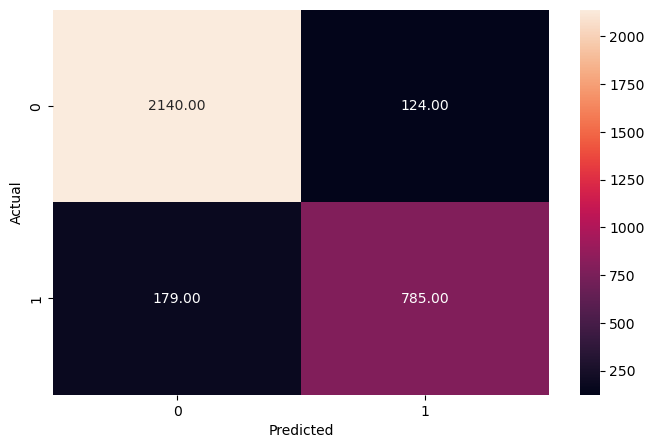

```python
#Checking the performance of the pruned random forest to training data
rf_class_pred_train_tuned = rf_estimator.predict(x_train)
metrics_score(y_train, rf_class_pred_train_tuned)
```

```
              precision    recall  f1-score   support

           0       0.89      0.92      0.91       971
           1       0.80      0.73      0.77       413

    accuracy                           0.87      1384
   macro avg       0.85      0.83      0.84      1384
weighted avg       0.86      0.87      0.86      1384
```

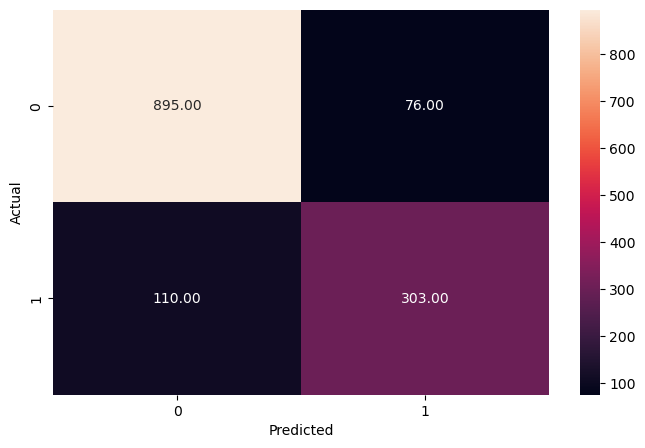

```python
#Checking the performance of the pruned random forest to test data
rf_class_pred_test_tuned = rf_estimator.predict(x_test)
metrics_score(y_test, rf_class_pred_test_tuned)
```

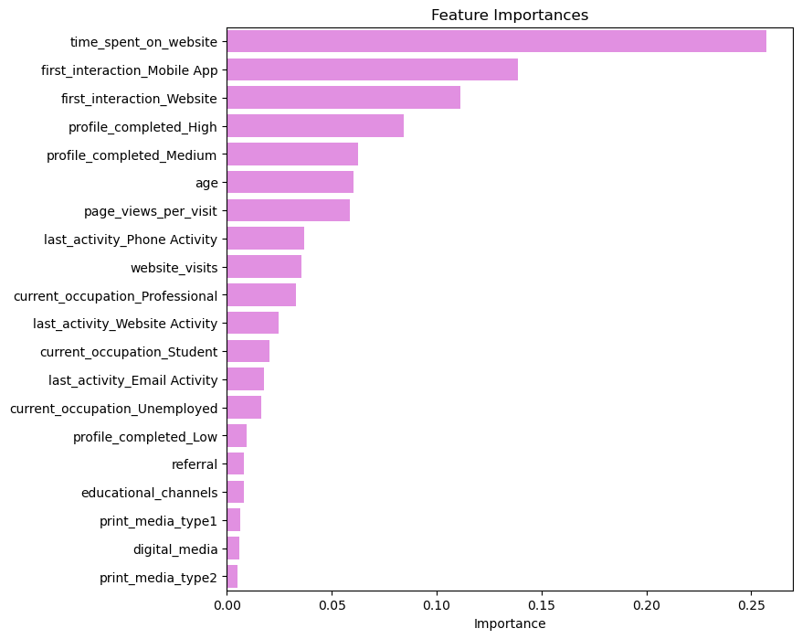

```python
#List out the features on which the tree splits and their importances
rf_importances = rf_estimator.feature_importances_

columns = x_train.columns

importance_rf = pd.DataFrame(rf_importances, index = columns, columns = ['Importance']).sort_values(by = 'Importance', ascending = False)


plt.figure(figsize=(8, 8))
plt.title("Feature Importances")
sns.barplot(x = importance_rf.Importance, y = importance_rf.index, color="violet")
```

## Actionable Insights and Recommendations

**Insights**